# Lecture12_assignment

# General linear model and model comparison

We wnat to increase the complexity of the model by adding multiple regressors, as necessary, to capture as much variance in the neural data as possible. Let’s start by examining our regressor set for potential collinearity. You can do this by generating a correlation matrix for the regressors and plotting it as an image (tip: consider using cor()) and image.plot() from the fields package)

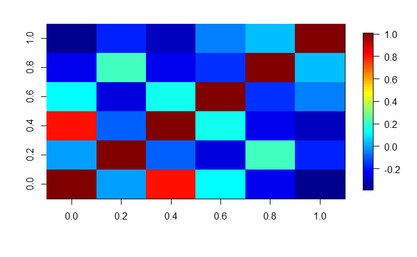

[output not shown]

[output not shown]

```r
summary(lm_0)
```

```
Call:
glm(formula = data$winprob ~ data$hfa)

Deviance Residuals:
     Min        1Q    Median        3Q       Max
-0.52855  -0.20135  -0.01824   0.20280   0.56843

Coefficients:
             Estimate Std. Error t value Pr(>|t|)
(Intercept)  0.548666   0.021471  25.554  < 2e-16 ***
data$hfa    -0.012242   0.002662  -4.598 7.87e-06 ***
---
Signif. codes:  0 ‘***’ 0.001 ‘**’ 0.01 ‘*’ 0.05 ‘.’ 0.1 ‘ ’ 1

(Dispersion parameter for gaussian family taken to be 0.07116459)

    Null deviance: 14.741  on 187  degrees of freedom
Residual deviance: 13.237  on 186  degrees of freedom
AIC: 40.671

Number of Fisher Scoring iterations: 2
```

```r
summary(lm_1)
```

```
Call:
glm(formula = data$winprob ~ data$hfa + data$rt)

Deviance Residuals:
     Min        1Q    Median        3Q       Max
-0.55062  -0.20189   0.00141   0.18826   0.58768

Coefficients:
             Estimate Std. Error t value Pr(>|t|)
(Intercept)  0.832488   0.082846  10.049  < 2e-16 ***
data$hfa    -0.011965   0.002585  -4.629  6.9e-06 ***
data$rt     -0.270408   0.076394  -3.540 0.000507 ***
---
Signif. codes:  0 ‘***’ 0.001 ‘**’ 0.01 ‘*’ 0.05 ‘.’ 0.1 ‘ ’ 1

(Dispersion parameter for gaussian family taken to be 0.06701091)

    Null deviance: 14.741  on 187  degrees of freedom
Residual deviance: 12.397  on 185  degrees of freedom
AIC: 30.352

Number of Fisher Scoring iterations: 2
```

[figure not shown]

[figure not shown]

[figure not shown]

[figure not shown]

[output not shown]

# ANOVA

Some people may hesitate more or less depending on whether the probability of winning is large or small. Thus we can hypothesize a relationship between RT and winprob. There are many multiple winprob levels, so a good way to test whether any differences in RT exist is through an ANOVA test.

- Run an ANOVA to test whether there are differences between mean RTs across winprob levels.

```r
#from: http://www.sthda.com/english/wiki/one-way-anova-test-in-r

res.aov <- aov(data$rt~data$winprob, data = data)
# Summary of the analysis
summary(res.aov)
```

[output not shown]

- (optional) If significant, you can run a Tukey post-hoc test to identify which differences are driving this relationship. To do this, you will need to convert the numerical winprob levels to factors (otherwise TukeyHSD() throws an error).

```r
win <- as.factor(data$winprob)
res.aov2<-aov(data$rt~win, data=data)
win
tu <-TukeyHSD(res.aov2)
plot(tu)
```

[output not shown]